# 3er Semana 26/05/2021- Algebra, Lógica, Conjuntos, Algebra relacional

# Introducción al pensamiento lógico con Python

## Introducción

Cuando pensamos, estamos realizando un complejo proceso que se inicia con la creación de imágenes mentales en nuestro cerebro. Estas imágenes las integramos, emparejamos, proyectamos o asociamos con nuestros conceptos o esquemas mentales que representan nuestra realidad en un proceso simbólico que necesitamos estructurar en secuencias que sigan un orden racionalmente definido. Gracias a este proceso, podemos prever lo que sucederá, evaluar las consecuencias de nuestros actos; y anticiparnos para evitar episodios desfavorables. Naturalmente, al ser seres humanos, este proceso de pensamiento puede verse afectado por nuestras emociones y otros factores físicos o sociales que prejuzgan nuestra manera de representar las cosas. Una de las herramientas que tenemos para evitar errores en nuestro pensamiento es la [lógica](https://es.wikipedia.org/wiki/L%C3%B3gica).

## ¿Qué es la Lógica?

Una de las principales herramientas que poseemos para intentar comprender la realidad que nos rodea es la [lógica](https://es.wikipedia.org/wiki/L%C3%B3gica). Más formalmente la [lógica](https://es.wikipedia.org/wiki/L%C3%B3gica) es un arte en la ciencia de la comprensión o el razonamiento. Se trata de avanzar en nuestra comprensión de una manera ordenada y correcta y que nos brinde facilidad.

El propósito de la [lógica](https://es.wikipedia.org/wiki/L%C3%B3gica) es guiar de manera precisa los pensamientos que, de no ser exactos, fallarían.

### Lógica y argumentación

Los seres humanos tenemos la capacidad para establecer y verificar *hechos*, cambiar o justificar *opiniones*, y en general, dar sentido a las cosas. Hacemos esto a través de la *razón*; si bien todos somos capaces de *razonar*, alarmantemente solo un porcentaje pequeño de nosotros lo hace realmente bien.

La [lógica](https://es.wikipedia.org/wiki/L%C3%B3gica) es la ciencia que se usa para evaluar un [argumento](https://es.wikipedia.org/wiki/Argumento). Un [argumento](https://es.wikipedia.org/wiki/Argumento) es un intento de persuadir a alguién de algo a través de darle razones para aceptar una conclusión dada. Utilizamos y escuchamos [argumentos](https://es.wikipedia.org/wiki/Argumento) todos los días e incluso muchas veces sin darnos cuenta de ello. Si queremos reconocer un buen [argumento](https://es.wikipedia.org/wiki/Argumento) de uno malo y ganar argumentaciones, entonces debemos dominar los mecanismos de la racionalidad pura, es decir, las leyes de la [lógica](https://es.wikipedia.org/wiki/L%C3%B3gica).

Un [argumento](https://es.wikipedia.org/wiki/Argumento) esta hecho de *premisas* y una *conclusión*. Las *premisas* suelen ser referidas también como *razones* o *evidencias*; en esencia, son simples proposiciones o declaraciones que se presentan para ser aceptadas como válidas. La *conclusión* no se más que la proposición final del [argumento](https://es.wikipedia.org/wiki/Argumento). Si el [argumento](https://es.wikipedia.org/wiki/Argumento) es válido, las *premisas* implican la *conclusión*.

### Lógica inductiva y deductiva

En general, usamos dos tipos de [lógica](https://es.wikipedia.org/wiki/L%C3%B3gica), [deductiva](https://es.wikipedia.org/wiki/Razonamiento_deductivo) e [inductiva](https://es.wikipedia.org/wiki/Razonamiento_inductivo). Las [inferencias deductivas](https://es.wikipedia.org/wiki/Razonamiento_deductivo) empiezan con un conocimiento general y predicen una observación específica; es decir que, en esta forma de razonamiento, la *conclusión* sigue necesariamente a las *premisas*. El ejemplo clásico es:

```
premisa 1:  Todos los humanos son mortales.
premisa 2:  Socrates es humano.
conclusión: Socrates es mortal.
```

Las [inferencias inductivas](https://es.wikipedia.org/wiki/Razonamiento_inductivo) hacen lo contrario. Comienzan con observaciones de una experiencia particular y llegan a conclusiones generales. En la [inducción](https://es.wikipedia.org/wiki/Razonamiento_inductivo), la *conclusión* se basa simplemente en una [probabilidad](https://relopezbriega.github.io/tag/probabilidad.html). El ejemplo clásico es:

```
premisa 1:  El sol ha salido todos los días hasta ahora.
conclusión: Por lo tanto, el sol saldrá mañana.
```

La solución de problemas demasiado complicados para ser resueltos por medio del sentido común se logra mediante largas series de inferencias mezcladas, tanto [inductivas](https://es.wikipedia.org/wiki/Razonamiento_inductivo) como [deductivas](https://es.wikipedia.org/wiki/Razonamiento_deductivo), que se entrelazan entre la experiencia observada y se formalizan como el [método científico](https://es.wikipedia.org/wiki/M%C3%A9todo_cient%C3%ADfico). El propósito real del [método científico](https://es.wikipedia.org/wiki/M%C3%A9todo_cient%C3%ADfico) es asegurarnos de que la Naturaleza no nos ha inducido a pensar que sabemos algo que en realidad ignoramos. Un solo desliz [lógico](https://es.wikipedia.org/wiki/L%C3%B3gica) y se derrumba todo un edificio científico.

## Falacias

La importancia de conocer los mecanismos de la [lógica](https://es.wikipedia.org/wiki/L%C3%B3gica) radica en tratar de comprender si un [argumento](https://es.wikipedia.org/wiki/Argumento) que alguien dice es *lógicamente* consistente; ya que si es inconsistente, implica que no deberíamos creer lo que esa persona nos dice. Lo más importante a tener en cuenta es la *verdad* de sus *premisas*; es decir, si éstas *premisas* se sustentan en evidencias y observaciones de la realidad.

Una [falacia](https://es.wikipedia.org/wiki/Falacia) es un error de razonamiento que invalida un argumento. Una de las características básicas del pensamiento lógico es la capacidad para detectar errores en las *conclusiones* o en las *premisas* de un determinado [argumento](https://es.wikipedia.org/wiki/Argumento) para poder evitar los razonamientos falaces, ya que éstos nos dificultan llegar a conocer la verdad de los hechos y nos hacen más susceptibles a la manipulación y la tergiversación. Las [falacia](https://es.wikipedia.org/wiki/Falacia) son, en definitiva, afirmaciones sin fundamento que a menudo se proclaman con una convicción que las hace sonar como si fueran hechos probados. Basta dedicar cinco minutos a escuchar las noticias o a leer la sección de política para encontrar cientos de ejemplos de [falacias](https://es.wikipedia.org/wiki/Falacia)! Veamos algunas de las más comunes:

1. **Falacia “ad hominem”:** Los ataques personales son contrarios a los argumentos racionales. En lógica y retórica, un ataque personal se llama “ad hominem”, que en latín significa “contra el hombre”. En lugar de avanzar en un buen razonamiento, una falacia ad hominem reemplaza la argumentación lógica con un lenguaje ofensivo no relacionado con la verdad del asunto. (Muy común en la política argentina).
2. **Falacia de la apelación a la autoridad:** Esta falacia argumentativa, también denominada “ad verecundiam”, ocurre cuando hacemos mal uso de una autoridad. Este mal uso de la autoridad puede ocurrir de varias maneras; por ejemplo: podemos citar solo a las autoridades, alejándonos convenientemente de otras pruebas comprobables y concretas como si la opinión de los expertos fuera siempre correcta; o podemos citar autoridades irrelevantes, autoridades pobres o autoridades falsas.
3. **Falacia populista:** Esta falacia, también denominada argumento “ad populum”, supone que algo es cierto (o correcto o bueno) porque otras personas están de acuerdo con la persona que lo afirma; esto es, se acepta algo que se dice porque es popular.
4. **Falacia de la generalización apresurada:** Una generalización apresurada es una declaración general sin evidencia suficiente para respaldarla. Ésta se produce a partir de la prisa por llegar a una conclusión, lo que lleva a la persona que argumenta a cometer algún tipo de suposición ilógica o a emitir estereotipos, conclusiones injustificadas o exageraciones.
5. **Falacia del falso dilema:** Esta falacia argumentativa ocurre cuando fallamos al limitar las opciones a únicamente dos, cuando de hecho hay más opciones para elegir. A veces las opciones son entre una cosa, la otra, o ambas cosas juntas (no se excluyen entre sí). Y a veces hay una amplia gama de opciones.

Obviamente, esta es una muestra muy pequeña de las trampas en las que puede caer nuestro pensamiento. Hay cientos de ellas!

## Juegos de lógica

A mí mamá le gustan las revistas de pasatiempos, esas revistas que traen cientos de juegos entre los que se incluyen sopas de letras, palabras cruzadas, autodefinidos, etc. Si bien ella tiene una habilidad increíble para resolver todos los juegos relacionados con palabras...siempre tuvo muuuchas dificultades con los del tipo Quién es Quién; en esos juegos, nos presentan un número de afirmaciones y en base a ellas debemos aplicar lógica deductiva para obtener la información faltante. Aquí va un ejemplo:

Tenemos la siguiente información sobre cuatro personas:

- Esteban tiene un auto azul
- La persona que tiene un gato vive en España. Matías vive en Argentina
- La persona con el auto negro vive en Brasil.
- Juan tiene un gato.
- Alex vive en Brasil
- La persona que tiene un perro vive en Colombia.
- ¿Quién tiene un conejo?

El objetivo entonces es, a partir de estas afirmaciones, deducir quién es el dueño del conejo.

Aquellos lo suficientemente valientes para intentar resolver el enigma con sus propios medios, pueden dejar de leer y recurrir al viejo método de papel y lápiz para arribar a la solución...los que prefieren aplicar la ley del menor esfuerzo (como es mi caso) pueden continuar leyendo para ver como con la ayuda de [Python](https://www.python.org/) y la librería [kanren](https://github.com/logpy/logpy), una librería que nos ayuda a implementar el paradigma de la [programación lógica](https://es.wikipedia.org/wiki/Programaci%C3%B3n_l%C3%B3gica); podemos resolver este enigma lógico y encontrar su solución.

```python
pip install kanren
```

```python
# <!-- collapse=True -->
# Importando las librerías que vamos a utilizar
from kanren import run, var, eq, membero
from kanren.core import lall
```

```python
# Enigma de Lógica
# Declaro la variable gente
gente = var()
```

```python
# Defino las reglas
reglas = lall(
    # hay 4 personas
    (eq, (var(), var(), var(), var()), gente),
    # Esteban tiene un auto azul
    (membero, ('Esteban', var(), 'azul', var()), gente),     # La persona que tiene un gato vive en España.
    (membero, (var(), 'gato', var(), 'España'), gente),      # Matías vive en Argentina
    (membero, ('Matías', var(), var(), 'Argentina'), gente), # La persona con el auto negro vive en Brasil.
    (membero, (var(), var(), 'Negro', 'Brasil'), gente),     # Juan tiene un gato.
    (membero, ('Juan', 'gato', var(), var()), gente),        # Alex vive en Brasil
    (membero, ('Alex', var(), var(), 'Brasil'), gente),      # La persona que tiene un perro vive en Colombia.
    (membero, (var(), 'perro', var(), 'Colombia'), gente),   # ¿Quién tiene un conejo?
    (membero, (var(), 'conejo', var(), var()), gente)
)
```

```python
# Ejecuto la solución
soluciones = run(0, gente, reglas)
```

```python
# Extraigo la respuesta
dueño = [nombre for nombre in soluciones[0] if 'conejo' in nombre][0][0]
# Imprimo los resultados.
print('\n' + dueño + ' es el dueño del conejo')
```

```
Matías es el dueño del conejo
```

```python
print('\n Detalle del enigma:')
atributos = ['Nombre', 'Mascota', 'Color de auto', 'País']
print('\n' + '\t\t'.join(atributos))
print('=' * 60)
for item in soluciones[0]:
    print('')
    print('\t\t'.join([str(x) for x in item]))
```

```
 Detalle del enigma:

Nombre		Mascota		Color de auto		País
============================================================

Esteban		perro		azul		Colombia

Juan		gato		~_9		España

Matías		conejo		~_11		Argentina

Alex		~_13		Negro		Brasil
```

Como podemos ver en el detalle del enigma, con la información proporcionada todavía hay datos que no podemos deducir, pero a pesar de la información incompleta, el programa sí pudo deducir la pregunta que estábamos buscando. Matías, que vive en Argentina, es el dueño del conejo.

Aquí finaliza este artículo. Si bien la [lógica](https://es.wikipedia.org/wiki/L%C3%B3gica) es una herramienta muy útil dentro de la compleja maquinaria de nuestro pensamiento, y nos ayuda a pensar con más claridad y menos errores; no por ello debemos confiar ciegamente en ella y dejar de seguir nuestros instintos.

# Conjuntos con Python

## Introducción

Una característica notable de los seres humanos es su inherente necesidad y capacidad de agrupar objetos de acuerdo a criterios específicos. La idea de la clasificación de ciertos objetos en grupos similares, o *[conjuntos](https://es.wikipedia.org/wiki/Conjunto)*, es uno de los conceptos más fundamentales de la matemática moderna. La [teoría de conjuntos](https://es.wikipedia.org/wiki/Teor%C3%ADa_de_conjuntos) ha sido el marco unificador para todas las matemáticas desde que el matemático alemán [Georg Cantor](https://es.wikipedia.org/wiki/Georg_Cantor) la formulara alrededor de 1870. Ningún campo de las matemáticas podría describirse hoy en día sin hacer referencia a algún tipo de [conjunto](https://es.wikipedia.org/wiki/Conjunto) abstracto. En términos más generales, el concepto de *membresía* de un [conjunto](https://es.wikipedia.org/wiki/Conjunto), que se encuentra en el corazón de la [teoría de conjuntos](https://es.wikipedia.org/wiki/Teor%C3%ADa_de_conjuntos), explica cómo sentencias con sustantivos y predicados son formulados en nuestro lenguaje, o en cualquier lenguaje abstracto como las matemáticas. Debido a esto, la [teoría de conjuntos](https://es.wikipedia.org/wiki/Teor%C3%ADa_de_conjuntos) está íntimamente ligada a la [lógica](https://es.wikipedia.org/wiki/L%C3%B3gica) y sirve de base para todas las matemáticas.

## ¿Qué es un conjunto?

**Un [conjunto](https://es.wikipedia.org/wiki/Conjunto) es una colección de objetos distintos, a menudo llamados elementos o miembros**. Existen dos características hacen de los [conjuntos](https://es.wikipedia.org/wiki/Conjunto) algo totalmente distinto a cualquier otra colección de objetos. En primer lugar, un [conjunto](https://es.wikipedia.org/wiki/Conjunto) está siempre "bien definido", es decir que si realizamos la pregunta *¿Este objeto particular, se encuentra en esta colección?*; siempre debe existir una respuesta clara por sí o por no basada en una regla o algunos criterios dados. La segunda característica, es que no hay dos miembros de un mismo [conjunto](https://es.wikipedia.org/wiki/Conjunto) que sean exactamente iguales, es decir, que no hay elementos repetidos. Un [conjunto](https://es.wikipedia.org/wiki/Conjunto) puede contener cualquier cosa imaginable, incluyendo números, letras, colores, incluso otros [conjuntos](https://es.wikipedia.org/wiki/Conjunto)!. Sin embargo, ninguno de los objetos del [conjunto](https://es.wikipedia.org/wiki/Conjunto) puede ser el propio [conjunto](https://es.wikipedia.org/wiki/Conjunto). Descartamos esta posibilidad para evitar encontrarnos con la [Paradoja de Russell](https://es.wikipedia.org/wiki/Paradoja_de_Russell), un problema famoso en la lógica matemática desenterrado por el gran lógico británico [Bertrand Russell](https://es.wikipedia.org/wiki/Bertrand_Russell) en 1901.

## Notación de Conjuntos

Cuando escribimos a los [conjuntos](https://es.wikipedia.org/wiki/Conjunto) utilizamos letras mayúsculas para sus nombres y para representar al [conjunto](https://es.wikipedia.org/wiki/Conjunto) propiamente dicho simplemente listamos sus elementos separándolos por comas y luego englobamos todos estos elementos dentro de un par de llaves. Así, por ejemplo, A = {1,2,3, ..., 10} es el [conjunto](https://es.wikipedia.org/wiki/Conjunto) de los 10 primeros [números naturales](https://es.wikipedia.org/wiki/N%C3%BAmero_natural) o para *contar*, B = {Rojo, Azul, Verde} es el [conjunto](https://es.wikipedia.org/wiki/Conjunto) de colores primarios, N = {1,2,3, ...} es el [conjunto](https://es.wikipedia.org/wiki/Conjunto) de todos los [números naturales](https://es.wikipedia.org/wiki/N%C3%BAmero_natural), y Z = {..., - 3, -2, -1,0,1,2,3, ...} es el [conjunto](https://es.wikipedia.org/wiki/Conjunto) de todos los [números enteros](https://es.wikipedia.org/wiki/N%C3%BAmero_entero). Los puntos suspensivos "..." se utilizan para describir el carácter *infinito* de los números en los conjuntos N y Z.

También se utiliza el símbolo $ \in $ para expresar que determina objeto pertenece o es *miembro* de un [conjunto](https://es.wikipedia.org/wiki/Conjunto) y el símbolo $ \notin $ para indicar que no pertenece a un [conjunto](https://es.wikipedia.org/wiki/Conjunto). Utilizando los ejemplos anteriores, podríamos por ejemplo escribir que $7 \in A$ y $12 \notin A$.

Dado que muchos [conjuntos](https://es.wikipedia.org/wiki/Conjunto) no se pueden describir listando todos sus miembros, ya que en muchos casos esto es imposible, también se utiliza la mucho más potente notación de constructor de conjuntos o predicado. En esta notación escribimos el conjunto de acuerdo a qué tipos de objetos pertenecen al [conjunto](https://es.wikipedia.org/wiki/Conjunto), que se colocan a la izquierda del símbolo "|", que significa "de tal manera que," dentro de las llaves; así como las condiciones que estos objetos deben cumplir para pertenecer al [conjunto](https://es.wikipedia.org/wiki/Conjunto), las cuales se colocan a la derecha de "|" dentro de las llaves. Por ejemplo, el [conjunto](https://es.wikipedia.org/wiki/Conjunto) de los [números racionales](https://es.wikipedia.org/wiki/N%C3%BAmero_racional), o fracciones, que se denota por Q no puede ser descrito por el método de listar todos sus miembros. En su lugar, se define a Q utilizando la notación de predicado de la siguiente manera: $Q=\{\frac{p}{q} \mid p, q \in Z$ y $q \ne 0 \}$ Esto se lee "Q es el conjunto de todas las fracciones de la forma p sobre q, tal que p y q son números enteros y q no es cero." También podríamos escribir al conjunto A de nuestro ejemplo anterior como $A = \{x \mid x \in N$ y $x < 11\}$.

## Conjuntos numéricos

Dentro de las matemáticas, los principales [conjuntos](https://es.wikipedia.org/wiki/Conjunto) numéricos que podemos encontrar y que tienen un carácter universal son:

- $\mathbb{N} = \{1,2,3, ...\}$ es el conjunto de los [números naturales](https://es.wikipedia.org/wiki/N%C3%BAmero_natural).
- $\mathbb{W} = \{0,1,2,3, ...\}$ es el conjunto de los [números enteros](https://es.wikipedia.org/wiki/N%C3%BAmero_entero) positivos.
- $\mathbb{Z} = \{...,-3,-2,-1,0,1,2,3, ...\}$ es el conjunto de todos los [números enteros](https://es.wikipedia.org/wiki/N%C3%BAmero_entero).
- $\mathbb{Q} =\{\frac{p}{q} \mid p, q \in Z$ y $q \ne 0 \}$ es el conjunto de los [números racionales](https://es.wikipedia.org/wiki/N%C3%BAmero_racional).
- $\mathbb{R}$, es el conjunto de los [números reales](https://es.wikipedia.org/wiki/N%C3%BAmero_real). Estos son todos los números que pueden ser colocados en una recta numérica unidimensional que se extiende sin fin tanto en negativo como positivo.
- $\mathbb{I}$, es el conjunto de los [números irracionales](https://es.wikipedia.org/wiki/N%C3%BAmero_irracional). Algunos de los números más importantes en matemáticas pertenecen a este conjunto,incluyendo $\pi, \sqrt{2}, e$ y $\phi$.
- $\mathbb{C}$, es el conjunto de los [números complejos](https://es.wikipedia.org/wiki/N%C3%BAmero_complejo). Estos son los números que contienen una parte real y otra parte imaginaria.

## Igualdad entre conjuntos

El concepto de igualdad en los [conjuntos](https://es.wikipedia.org/wiki/Conjunto), difiere levemente del clásico concepto de igualdad que solemos tener. Dos conjuntos A y B se dice que son iguales (expresado por A = B), si y sólo si ambos [conjuntos](https://es.wikipedia.org/wiki/Conjunto) tienen exactamente los mismos elementos. Por ejemplo el [conjunto](https://es.wikipedia.org/wiki/Conjunto) A={1,2,3,4} es igual al [conjunto](https://es.wikipedia.org/wiki/Conjunto) B={4,3,2,1}. Un [conjunto](https://es.wikipedia.org/wiki/Conjunto) importante, y que todavía no hemos mencionado es el **[conjunto vacío](https://es.wikipedia.org/wiki/Conjunto_vac%C3%ADo)**, el cual no tiene elementos y por tanto no puede ser igualado con ningún otro [conjunto](https://es.wikipedia.org/wiki/Conjunto). Se expresa con el símbolo $\emptyset$ o {}.

## Cardinalidad

La [cardinalidad](https://es.wikipedia.org/wiki/Conjunto#Cardinalidad) de un [conjunto](https://es.wikipedia.org/wiki/Conjunto) A es el número de elementos que pertenecen a A y lo expresamos como n(A). La [cardinalidad](https://es.wikipedia.org/wiki/Conjunto#Cardinalidad) de un [conjunto](https://es.wikipedia.org/wiki/Conjunto) puede ser pensada tambien como una medida de su "tamaño". Si la [cardinalidad](https://es.wikipedia.org/wiki/Conjunto#Cardinalidad) de un [conjunto](https://es.wikipedia.org/wiki/Conjunto) es un [número entero](https://es.wikipedia.org/wiki/N%C3%BAmero_entero), entonces el conjunto se dice que es finito. De lo contrario, el conjunto se dice que es infinito. Así por ejemplo la [cardinalidad](https://es.wikipedia.org/wiki/Conjunto#Cardinalidad) del [conjunto](https://es.wikipedia.org/wiki/Conjunto) A={1,2,...,9,10} es 10 y lo expresamos como n(A)=10.

## Subconjunto y subconjunto propio

Si todos los elementos de un [conjunto](https://es.wikipedia.org/wiki/Conjunto) A son también elementos de otro [conjunto](https://es.wikipedia.org/wiki/Conjunto) B, entonces A se llama un [subconjunto](https://es.wikipedia.org/wiki/Subconjunto) de B y lo expresamos como $A \subseteq B$. En cierto sentido, se puede pensar al [subconjunto](https://es.wikipedia.org/wiki/Subconjunto) A como dentro, o contenido en el [conjunto](https://es.wikipedia.org/wiki/Conjunto) B. Si un [conjunto](https://es.wikipedia.org/wiki/Conjunto) A es un [subconjunto](https://es.wikipedia.org/wiki/Subconjunto) de B y los dos [conjuntos](https://es.wikipedia.org/wiki/Conjunto) no son iguales, entonces llamamos A un [subconjunto propio](https://es.wikipedia.org/wiki/Subconjunto#Subconjunto_propio) de B y lo expresamos como $A \subset B$. En este caso, se dice que el [conjunto](https://es.wikipedia.org/wiki/Conjunto) A esta propiamente contenido en B. Algunas propiedades importantes relacionadas con [subconjuntos](https://es.wikipedia.org/wiki/Subconjunto) y [subconjuntos propios](https://es.wikipedia.org/wiki/Subconjunto#Subconjunto_propio) son las siguientes:

- Cualquier [conjunto](https://es.wikipedia.org/wiki/Conjunto) A es un [subconjunto](https://es.wikipedia.org/wiki/Subconjunto) de sí mismo. Por lo tanto $A \subseteq A$. Esto es claramente cierto.
- Menos obvio es el hecho de que el [conjunto vacío](https://es.wikipedia.org/wiki/Conjunto_vac%C3%ADo) es un subconjunto de cualquier conjunto A. Por lo tanto $\emptyset \subseteq A$. Esta propiedad se prueba a través de la contradicción, ya que si asumimos que existe un [conjunto](https://es.wikipedia.org/wiki/Conjunto) A del que el [conjunto vacío](https://es.wikipedia.org/wiki/Conjunto_vac%C3%ADo) no es un [subconjunto](https://es.wikipedia.org/wiki/Subconjunto), entonces esto quiere decir que el [conjunto vacío](https://es.wikipedia.org/wiki/Conjunto_vac%C3%ADo) debe contener un elemento que no se encuentra en A y esto es absurdo ya que el [conjunto vacío](https://es.wikipedia.org/wiki/Conjunto_vac%C3%ADo) no contiene ningún elemento.
- El [conjunto vacío](https://es.wikipedia.org/wiki/Conjunto_vac%C3%ADo) es un [subconjunto propio](https://es.wikipedia.org/wiki/Subconjunto#Subconjunto_propio) de cualquier [conjunto](https://es.wikipedia.org/wiki/Conjunto) A, siempre y cuando A no se también un [conjunto vacío](https://es.wikipedia.org/wiki/Conjunto_vac%C3%ADo).
- Para los [conjuntos](https://es.wikipedia.org/wiki/Conjunto) finitos A y B, si $A \subseteq B$, entonces $n(A) \leq n(B)$.
- De forma similar, para los [conjuntos](https://es.wikipedia.org/wiki/Conjunto) finitos A y B, si $A \subset B$, entonces $n(A) < n(B)$.

## Conjunto potencia

El [conjunto potencia](https://es.wikipedia.org/wiki/Conjunto_potencia) de un [conjunto](https://es.wikipedia.org/wiki/Conjunto) A, expresado por $P_{A}$, es el [conjunto](https://es.wikipedia.org/wiki/Conjunto) formado por todos los distintos [subconjuntos](https://es.wikipedia.org/wiki/Subconjunto) de A. Así por ejemplo el [conjunto potencia](https://es.wikipedia.org/wiki/Conjunto_potencia) del [conjunto](https://es.wikipedia.org/wiki/Conjunto) $A=\{1,2,3\}$; va a ser igual a $P_{A}=\{\emptyset,\{1\},\{2\},\{3\},\{1,2\},\{2,3\}, \{1,3\},\{1,2,3\}\}$.

Un teorema importante de la [teoría de conjuntos](https://es.wikipedia.org/wiki/Teor%C3%ADa_de_conjuntos) establece que si A es un [conjunto](https://es.wikipedia.org/wiki/Conjunto) con k elementos, es decir que n(A) = k; entonces el [conjunto potencia](https://es.wikipedia.org/wiki/Conjunto_potencia) de A tiene exactamente $2^k$ elementos. Escribimos esto como $n(P_{A}) = 2^k$. En nuestro ejemplo anterior podemos ver que n(A)=3, por lo tanto $n(P_{A}) = 2^3$, lo que es igual a los 8 elementos que vimos que tiene el [conjunto potencia](https://es.wikipedia.org/wiki/Conjunto_potencia) de A.

## Algebra de conjuntos

El [álgebra de conjuntos](https://es.wikipedia.org/wiki/%C3%81lgebra_de_conjuntos) es el estudio de las operaciones básicas que podemos realizar con los [conjuntos](https://es.wikipedia.org/wiki/Conjunto). Las operaciones básicas del álgebra de conjuntos son:

- **Unión**. La [unión](https://es.wikipedia.org/wiki/Uni%C3%B3n_de_conjuntos) de dos conjuntos A y B es el conjunto $A \cup B$ que contiene todos los elementos de A y de B.

[figure not shown]

- **Intersección**. La [intersección](https://es.wikipedia.org/wiki/Intersecci%C3%B3n_de_conjuntos) de dos conjuntos A y B es el conjunto $A \cap B$ que contiene todos los elementos comunes de A y B.

[figure not shown]

- **Diferencia**. La [diferencia](https://es.wikipedia.org/wiki/Diferencia_de_conjuntos) entre dos conjuntos A y B es el conjunto $A \setminus B$ que contiene todos los elementos de A que no pertenecen a B.

[figure not shown]

- **Complemento**. El [complemento](https://es.wikipedia.org/wiki/Complemento_de_un_conjunto) de un conjunto A es el conjunto $A^∁$ que contiene todos los elementos que no pertenecen a A.

[figure not shown]

- **Producto cartesiano**. El [producto cartesiano](https://es.wikipedia.org/wiki/Producto_cartesiano) de dos conjuntos A y B es el conjunto $A \times B$ que contiene todos los pares ordenados (a, b) cuyo primer elemento pertenece a A y su segundo elemento pertenece a B.

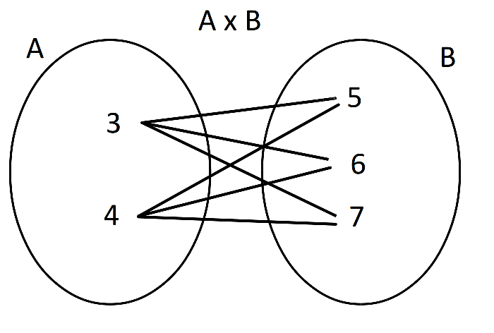

## Conjuntos con Python

Luego de todo este repaso por los fundamentos de la [teoría de conjuntos](https://es.wikipedia.org/wiki/Teor%C3%ADa_de_conjuntos), es tiempo de ver como podemos utilizar a los [conjuntos](https://es.wikipedia.org/wiki/Conjunto) dentro de [Python](https://www.python.org/); ya que el lenguaje trae como una de sus [estructuras de datos](https://es.wikipedia.org/wiki/Estructura_de_datos) por defecto a los [conjuntos](https://es.wikipedia.org/wiki/Conjunto). También veremos que podemos utilizar el *constructor* `FiniteSet` que nos proporciona [sympy](https://www.sympy.org/es/), el cual tiene ciertas ventajas sobre la versión por defecto de [Python](https://www.python.org/).

```python
# Creando un conjunto en python
A = {1,2,3}
A
```

```
{1, 2, 3}
```

```python
# Creando un conjunto a partir de una lista
lista = ["bananas", "manzanas", "naranjas", "limones"]
B = set(lista)
B
```

```
{'bananas', 'limones', 'manzanas', 'naranjas'}
```

```python
# Los conjuntos eliminan los elementos duplicados
lista = ["bananas", "manzanas", "naranjas", "limones",
        "bananas", "bananas", "limones", "naranjas"]
B = set(lista)
B
```

```
{'bananas', 'limones', 'manzanas', 'naranjas'}
```

```python
# Creando el conjunto vacío
O = set()
O
```

```
set()
```

```python
# Cardinalidad de un conjunto con len().
print("La cardinalidad del conjunto A = {0} es {1}".format(A,len(A)))
```

```
La cardinalidad del conjunto A = {1, 2, 3} es 3
```

```python
# comprobando membresía
2 in A
```

```
True
```

```python
# Igualdad entre conjuntos. El orden de los elementos no importa.
A = {1,2,3,4}
B = {4,2,3,1}
A == B
```

```
True
```

```python
# Subconjunto. No hay distincion entre subconjunto y propio
# para el conjunto por defecto de python.
A = {1,2,3}
B = {1,2,3,4,5}
A.issubset(B)
```

```
True
```

```python
# Subconjunto propio
A.issubset(B) and A != B
```

```
True
```

```python
# Union de conjuntos
A = {1,2,3,4,5}
B = {4,5,6,7,8,9,10}
A.union(B)
```

```
{1, 2, 3, 4, 5, 6, 7, 8, 9, 10}
```

```python
# Intersección de conjuntos
A.intersection(B)
```

```
{4, 5}
```

```python
# Diferencia entre conjuntos
A - B
```

```
{1, 2, 3}
```

```python
B - A
```

```
{6, 7, 8, 9, 10}
```

```python
# Utilizando FiniteSet de sympy
from sympy import FiniteSet
C = FiniteSet(1, 2, 3)
C
```

$\displaystyle \left\{1, 2, 3\right\}$

```python
# Generando el conjunto potencia. Esto no se puede
# hacer utilizando el conjunto por defecto de python.
C.powerset()
```

$\displaystyle \left\{\emptyset, \left\{1\right\}, \left\{2\right\}, \left\{3\right\}, \left\{1, 2\right\}, \left\{1, 3\right\}, \left\{2, 3\right\}, \left\{1, 2, 3\right\}\right\}$

```python
# Cardinalidad
print("La cardinalidad del conjunto potencia del conjunto C = {0} es {1}".
     format(C, len(C.powerset())))
```

```
La cardinalidad del conjunto potencia del conjunto C = FiniteSet(1, 2, 3) es 8
```

```python
# Igualdad
A = FiniteSet(1, 2, 3)
B = FiniteSet(1, 3, 2)
A == B
```

```
True
```

```python
A = FiniteSet(1, 2, 3)
B = FiniteSet(1, 3, 4)
A == B
```

```
False
```

```python
# Subconjunto y subconjunto propio
A = FiniteSet(1,2,3)
B = FiniteSet(1,2,3,4,5)
A.is_subset(B)
```

```
True
```

```python
A.is_proper_subset(B)
```

```
True
```

```python
# A == B. El test de subconjunto propio da falso
B = FiniteSet(2,1,3)
A.is_proper_subset(B)
```

```
False
```

```python
# Union de dos conjuntos
A = FiniteSet(1, 2, 3)
B = FiniteSet(2, 4, 6)
A.union(B)
```

$\displaystyle \left\{1, 2, 3, 4, 6\right\}$

```python
# Interseccion de dos conjuntos
A = FiniteSet(1, 2)
B = FiniteSet(2, 3)
A.intersect(B)
```

$\displaystyle \left\{2\right\}$

```python
# Diferencia entre conjuntos
A - B
```

$\displaystyle \left\{1\right\}$

```python
# Calculando el producto cartesiano. Con el conjunto por
# defecto de python no podemos hacer esto con el operador *
A = FiniteSet(1, 2)
B = FiniteSet(3, 4)
P = A * B
P
```

$\displaystyle \left\{1, 2\right\} \times \left\{3, 4\right\}$

```python
for elem in P:
    print(elem)
```

```
(1, 3)
(2, 3)
(1, 4)
(2, 4)
```

```python
# Elevar a la n potencia un conjunto. Calcula el n
# producto cartesiano del mismo conjunto.
A = FiniteSet(1, 2, 3, 4)
P2 = A ** 2
P2
```

$\displaystyle \left\{1, 2, 3, 4\right\}^{2}$

```python
P3 = A ** 3
P3
```

$\displaystyle \left\{1, 2, 3, 4\right\}^{3}$

```python
for elem in P3:
    print(elem)
```

```
(1, 1, 1)
(2, 1, 1)
(1, 2, 1)
(3, 1, 1)
(2, 2, 1)
(1, 1, 2)
(4, 1, 1)
(3, 2, 1)
(2, 1, 2)
(1, 3, 1)
(4, 2, 1)
(3, 1, 2)
(2, 3, 1)
(1, 2, 2)
(4, 1, 2)
(3, 3, 1)
(2, 2, 2)
(1, 1, 3)
(4, 3, 1)
(3, 2, 2)
(2, 1, 3)
(1, 4, 1)
(4, 2, 2)
(3, 1, 3)
(2, 4, 1)
(1, 3, 2)
(4, 1, 3)
(3, 4, 1)
(2, 3, 2)
(1, 2, 3)
(4, 4, 1)
(3, 3, 2)
(2, 2, 3)
(1, 1, 4)
(4, 3, 2)
(3, 2, 3)
(2, 1, 4)
(1, 4, 2)
(4, 2, 3)
(3, 1, 4)
```

[output cut: 9 more lines]

```
(1, 4, 3)
(4, 3, 3)
(3, 2, 4)
(2, 4, 3)
(1, 3, 4)
(4, 2, 4)
(3, 4, 3)
(2, 3, 4)
(1, 4, 4)
(4, 4, 3)
(3, 3, 4)
(2, 4, 4)
(4, 3, 4)
(3, 4, 4)
(4, 4, 4)
```

```python
# graficos embebidos
%matplotlib inline
```

```python
pip install matplotlib_venn
```

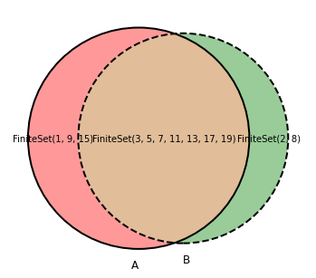

```python
# Dibujanto el diagrama de venn de 2 conjuntos
from matplotlib_venn import venn2, venn2_circles
import matplotlib.pyplot as plt

A = FiniteSet(1, 3, 5, 7, 9, 11, 13, 15, 17, 19)
B = FiniteSet(2, 3, 5, 7, 11, 13, 17, 19, 8)

plt.figure(figsize=(6, 8))
v = venn2(subsets=[A, B], set_labels=('A', 'B'))
v.get_label_by_id('10').set_text(A - B)
v.get_label_by_id('11').set_text(A.intersection(B))
v.get_label_by_id('01').set_text(B - A)
c = venn2_circles(subsets=[A, B], linestyle='dashed')
c[0].set_ls('solid')
plt.show()
```

## Algebra y Probabilidad

### Espacio muestral

Al conjunto formado por todos los posibles resultados elementales de un experimento aleatorio se le denomina espacio muestral de dicho experimento. Si consideramos, por ejemplo, el experimento consistente en el lanzamiento de una moneda:

Los sucesos elementales son Cara (C) y Cruz (X)

El espacio muestral asociado a dicho experimento es: E = {C, X}

En la siguiente escena puedes observar algunos ejemplos de experimentos aleatorios, sus espacios muestrales y cómo construirlos.

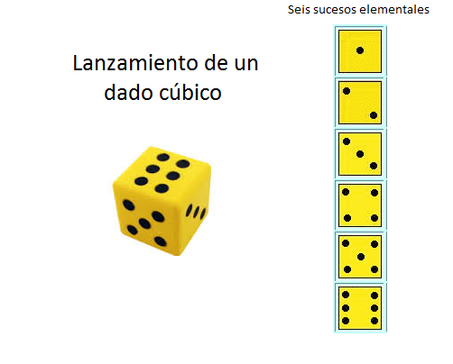

### Sucesos y tipos de sucesos

En el contexto probabilístico, denominamos suceso a cualquier subconjunto de un espacio muestral; esto es, a cualquier posible resultado de un experimento aleatorio.

#### Suceso elemental

Un suceso se dice que es un suceso elemental si está formado por un único elemento del espacio muestral. Por ejemplo, al tirar un dado el suceso consistente en obtener un cinco.

#### Suceso compuesto

Un suceso se dice que es un suceso compuesto si está formado por más de un elemento del espacio muestral. En el mismo ejemplo anterior obtener un número par, es decir, que salga un 2 o un 4 o un 6.

Entre los diferentes sucesos destacaremos los siguientes:

#### Suceso seguro

El suceso seguro es aquél que está formado por todos los resultados posibles del espacio muestral (E), es decir aquél que se cumple siempre. Por ejemplo al tirar un dado cúbico obtener un número del uno al seis.

#### Suceso imposible

El suceso imposible es aquél que no ocurre nunca. Se expresa con el símbolo Ø. Por ejemplo, obtener un ocho al tirar un dado cúbico.

#### Notación suceso complementario

En la escena siguiente puedes observar algunos ejemplos de un suceso y del suceso contrario o complementario.

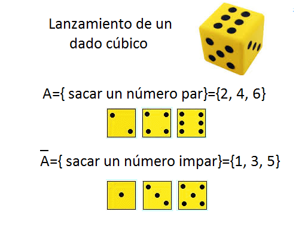

### Álgebra de Boole de sucesos. Leyes de Morgan

El conjunto de todos los sucesos de un espacio muestral junto con las operaciones unión e intersección definidas anteriormente, cumple una serie de propiedades que lo dotan de una estructura matemática conocida como álgebra de Boole. En el siguiente cuadro se resumen las propiedades y consecuencias directas más importantes.

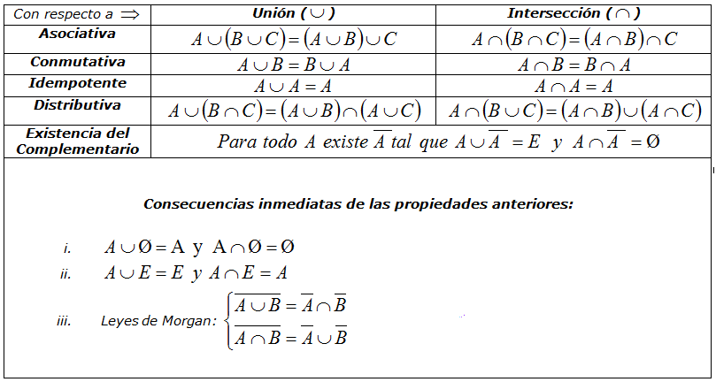

Las leyes de Morgan son de gran utilidad. Su aplicación permite, en muchas situaciones, calcular probabilidades de un suceso a partir de las probabilidades de otros que sean más fáciles o bien cuando necesitamos apoyarnos en algunas probabilidades que se den como datos.

https://es.wikipedia.org/wiki/Leyes_de_De_Morgan

## Algebra relacional.

Los sistemas de gestión de bases de datos (DBMS) deben tener un lenguaje de consulta para que los usuarios puedan acceder a los datos almacenados en la base de datos. El álgebra relacional (RA) se considera como un lenguaje de consulta procedimental donde el usuario le dice al sistema que lleve a cabo un conjunto de operaciones para obtener los resultados deseados. es decir, el usuario dice qué datos deben recuperarse de la base de datos y cómo recuperarlos.

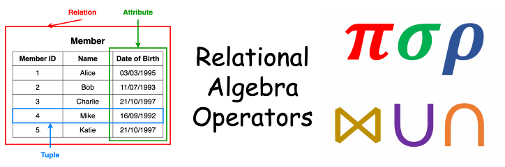

### ¿Qué es el álgebra relacional?

El álgebra relacional es una familia de álgebras con una semántica bien fundada que se utiliza para modelar los datos almacenados en bases de datos relacionales y definir consultas sobre ellos.

RA proporciona una base teórica para bases de datos relacionales. Supongo que conoce los términos básicos que se utilizan en las bases de datos relacionales. Ahora preste atención a los términos relación , atributo y tupla como se indica en la Figura 1.

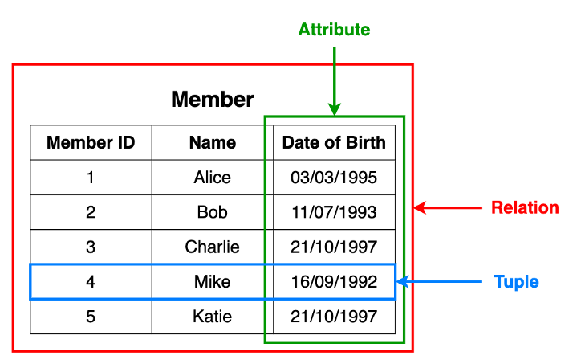

Analizaremos los siguientes operadores de RA.

- Proyección
- Selección
- Rebautizar
- Producto cruzado o Cartesiano
- Unión natural
- Unión condicional
- Unión
- Intersección
- Establecer diferencia

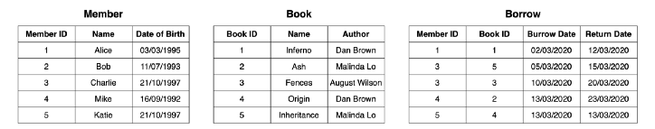

### Proyección (π)

La proyección se utiliza para seleccionar las columnas de datos requeridas de una relación. Tenga en cuenta que la proyección elimina los datos duplicados (tuplas).

Consulta: ID de miembros de los miembros que han pedido libros prestados.

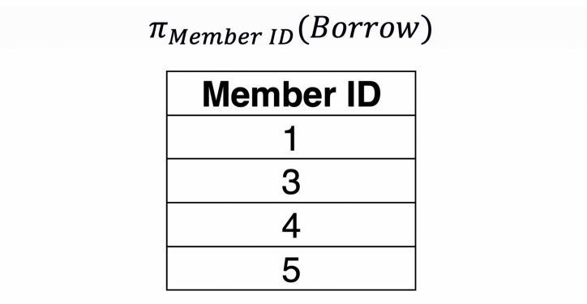

Consulta: ID de miembros de los miembros y los ID de libros de los libros que han tomado prestados.

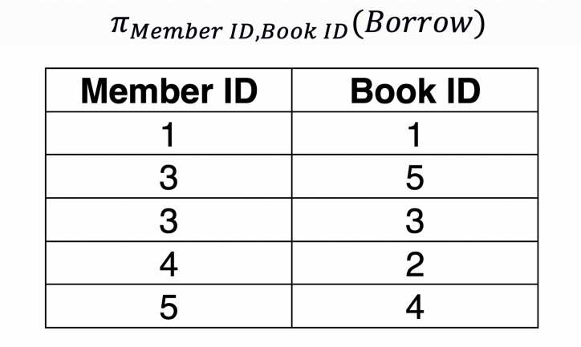

### Selección (σ)

La selección se utiliza para seleccionar las tuplas de datos necesarias de una relación. Durante la selección, podemos especificar ciertas condiciones que los datos deben cumplir.

[figure not shown]

### Cambiar nombre (ρ)

La operación de cambio de nombre permite cambiar el nombre de una determinada relación de salida.

Consulta: cambie el nombre de la relación Miembro como LibraryMemebr.

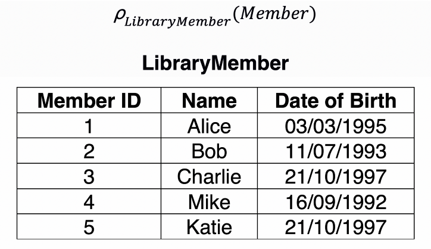

### Producto cruzado (✕) o Cartesiano

El producto cruzado se utiliza para combinar datos de dos relaciones diferentes en una relación combinada. Si consideramos dos relaciones; A con n tuplas y B con m tuplas, A ✕ B constará de nm tuplas.

Consulta: Miembro ✕ Préstamo

Tenga en cuenta que la relación Member tiene 5 tuplas y la relación Burrow tiene 5 tuplas. Por lo tanto, el miembro ✕ Préstamo tiene 5✕5 = 25 tuplas.

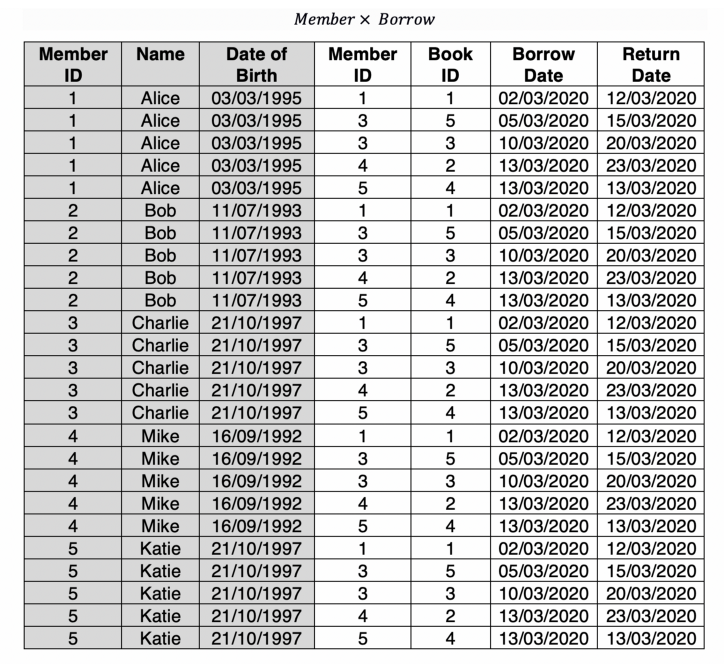

### Unión natural (⋈)

La unión natural entre dos o más relaciones dará como resultado todas las combinaciones de tuplas donde tienen valores iguales para el atributo común.

Consulta: Miembro ⋈ Préstamo

Tenga en cuenta que el atributo común en este ejemplo es ID de miembro.

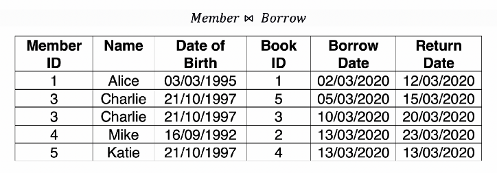

### Unión condicional (⋈c)

La combinación condicional es similar a la combinación natural, pero en la combinación condicional, podemos especificar cualquier condición de combinación con los operadores mayor que, menor que, igual o no igual. También puede combinar condiciones con los operadores AND (^) y OR (v).

Consulta: detalles de préstamos de miembros que han excavado más de un libro.

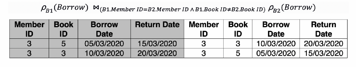

Unión (⋃) La operación de unión en RA es muy similar a la de la teoría de conjuntos. Sin embargo, para la unión de dos relaciones, ambas relaciones deben tener el mismo conjunto de atributos.

Consulta: ID de libros de los libros prestados por Charlie y Mike.

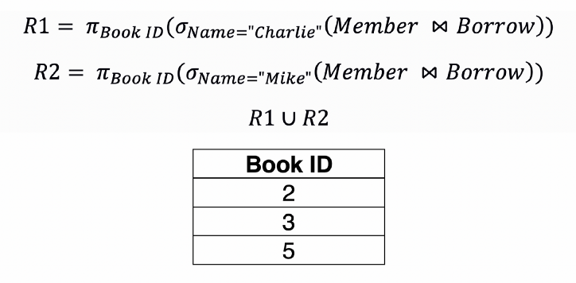

### Intersección (⋂)

La operación de intersección en RA es muy similar a la de la teoría de conjuntos. Sin embargo, para la intersección de dos relaciones, ambas relaciones deben tener el mismo conjunto de atributos.

Consulta: ID de miembro de los miembros que han tomado prestados los libros "Fences" y "Inheritance".

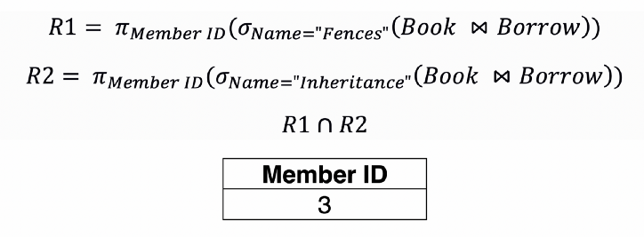

### Establecer diferencia (-)

La operación de diferencias de conjuntos en RA es muy similar a la de la teoría de conjuntos. Sin embargo, para el conjunto de diferencias entre dos relaciones, ambas relaciones deben tener el mismo conjunto de atributos.

Consulta: ID de miembros de los miembros que nunca han pedido libros prestados.

R1 devolverá detalles de todos los miembros Alice, Bob, Charlie, Mike y Katie. R2 devolverá detalles de Alice, Charlie, Mike y Katie, ya que tomaron libros prestados. Cuando tomamos la diferencia entre R1 y R2, se devolverán los detalles de Bob.

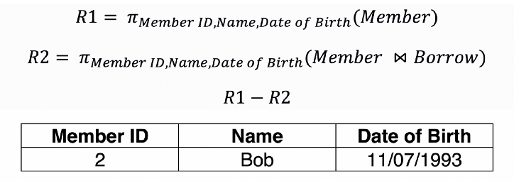

```python
### Levadas a SQL

-- Create Member table
CREATE TABLE member(
   member_id INT PRIMARY KEY,
   name VARCHAR (50) NOT NULL,
   date_of_birth DATE NOT NULL
);

-- Add records to Member table
INSERT INTO member VALUES (1, 'Alice', '1995-03-03');
INSERT INTO member VALUES (2, 'Bob', '1993-03-05');
INSERT INTO member VALUES (3, 'Charlie', '1997-10-21');
INSERT INTO member VALUES (4, 'Mike', '1992-09-16');
INSERT INTO member VALUES (5, 'Katie', '1997-10-21');


-- Create Book table
CREATE TABLE book(
   book_id INT PRIMARY KEY,
   name VARCHAR (50) NOT NULL,
   author VARCHAR (50) NOT NULL
);

-- Add records to Book table
INSERT INTO book VALUES (1, 'Inferno', 'Dan Brown');
INSERT INTO book VALUES (2, 'Ash', 'Malinda Lo');
INSERT INTO book VALUES (3, 'Fences', 'August Wilson');
INSERT INTO book VALUES (4, 'Origin', 'Dan Brown');
INSERT INTO book VALUES (5, 'Inheritance', 'Malinda Lo');


-- Create Borrow table
CREATE TABLE borrow(
   member_id INT REFERENCES member(member_id),
   book_id INT REFERENCES book(book_id),
   borrow_date DATE NOT NULL,
   return_date DATE NOT NULL
);

-- Add records to Borrow table
INSERT INTO borrow VALUES (1, 1, '2020-03-02', '2020-03-12');
INSERT INTO borrow VALUES (3, 5, '2020-03-05', '2020-03-15');
INSERT INTO borrow VALUES (3, 3, '2020-03-10', '2020-03-20');
INSERT INTO borrow VALUES (4, 2, '2020-03-13', '2020-03-23');
INSERT INTO borrow VALUES (5, 4, '2020-03-13', '2020-03-13');
```

[output not shown]

```python
-- Projection example
SELECT DISTINCT member_id FROM borrow;
SELECT DISTINCT member_id,book_id FROM borrow;

-- Selection example
SELECT * FROM member WHERE date_of_birth='1997-10-21';

-- Rename example
WITH library_member AS (SELECT * FROM member) SELECT * FROM library_member;

-- Cross product example
SELECT * FROM member,borrow;

-- Natural join example
SELECT * FROM member NATURAL JOIN borrow;

-- Conditional join example
WITH B1 AS (SELECT * from borrow), B2 AS (SELECT * from borrow)
SELECT * FROM B1 INNER JOIN B2 ON B1.member_id=B2.member_id AND B1.book_id<>B2.book_id;

-- Union example
SELECT book_id FROM member natural join borrow where name='Charlie' UNION
SELECT book_id FROM member natural join borrow where name='Mike';

-- Intersection example
SELECT member_id FROM book natural join borrow where name='Fences' INTERSECT
SELECT member_id FROM book natural join borrow where name='Inheritance';

-- Set difference example
SELECT member_id,name,date_of_birth FROM member EXCEPT
SELECT member_id,name,date_of_birth FROM member natural join borrow;
```

[output not shown]

Además de las aplicaciones que pueden tener los conjuntos de Python en matemáticas, los mismos también pueden ser una estructura de datos poderosa y ayudarnos a resolver varios problemas de programación en forma muy sencilla. A tenerlos en cuenta!